# Regressing with T and E scalar anisotropies (no lensing B-modes)

To get more realistic simulations we include $E$ -modes polarization to the signal to be observed. So that, now pair differences encode a non-null signal. *We keep 10 minutes as the gain drift time scale.*

```python
import scipy as sp
from scipy import interpolate
from scipy import optimize
from scipy import integrate
from iminuit import  Minuit
import numpy as np
import pylab as pl
import healpy as hp
mapdic={0:'T',1:'Q', 2:'U'}

lmax=500
l=pl.arange(2, lmax+1)
bl=hp.gauss_beam(lmax=lmax, fwhm=pl.deg2rad(30/60))[2:]
Nl_0=lambda w: (pl.pi /180. /60. * w)**2
```

### Signal-only maps w/o systematics

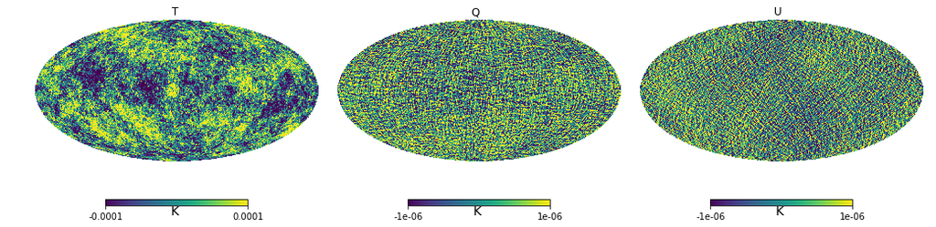

```python
sigonlymap = hp.read_map(field=range(3) ,
                       filename='/Users/peppe/work/satellite_sims/sigonly/scalar_only/madam_bmap.fits',
                      verbose=False)
fig=pl.figure(figsize=(14,12))
hp.mollview(sigonlymap[0]  , unit='K ', title=' T  ', sub=131 , fig=fig, min=-1e-4 , max=1e-4 )
hp.mollview(sigonlymap [1] , unit='K ', title='Q  ', sub=132 , fig=fig , min=-1e-6 , max=1e-6   )
hp.mollview(sigonlymap [2], unit='K ', title='U  ', sub=133 , fig=fig , min=-1e-6, max=1e-6 )
#cl =hp.anafast(sigonlymap    , lmax=lmax)
```

### Signal-only maps w/ gain drifts

(aka *pre-correction* maps)

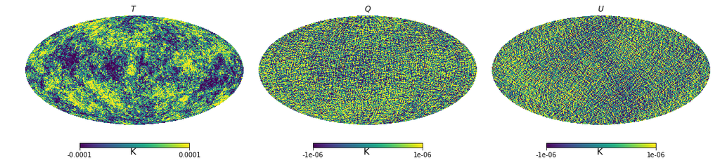

```python
driftmap= hp.read_map(field=range(3) ,
                       filename='/Users/peppe/work/satellite_sims/sigonly/uncorr/scalar_only/10min/madam_bmap.fits',
                       verbose=False)
fig=pl.figure(figsize=(15,8))
hp.mollview(  driftmap [0]   , unit='K ', title=r'$  T$  ', sub=131 , fig=fig , min=-1e-4 , max=1e-4   )
hp.mollview(driftmap [1] , unit='K ', title=r'$  Q$', sub=132 , fig=fig, min=-1e-6 , max=1e-6  )
hp.mollview(driftmap [2]  , unit='K ', title=r'$ U$', sub=133 , fig=fig  , min=-1e-6 , max=1e-6 )
#cldrifts = hp.anafast(driftmap   , lmax=lmax)
```

The T->P leakage injected by gain drifts is at order of some percentage of the signal (so that we barely notice variation in the maps)

### Signal-only maps w/ gain drifts corrected

(aka *post-correction* maps)

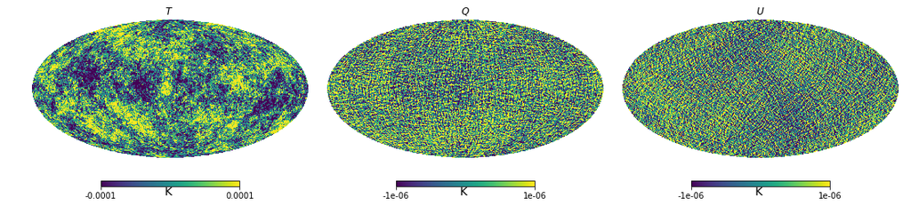

```python
driftcorrmap= hp.read_map(field=range(3) ,
                       filename='/Users/peppe/work/satellite_sims/sigonly/corr/scalar_only/10min/madam_bmap.fits',
                       verbose=False)
fig=pl.figure(figsize=(15,8))
hp.mollview(driftcorrmap [0]  , unit='K ', title=r'$ T$  ', sub=131 , fig=fig, min=-1e-4 , max=1e-4   )
hp.mollview(driftcorrmap [1] , unit='K ', title=r'$ Q$', sub=132 , fig=fig , min=-1e-6 , max=1e-6  )
hp.mollview(driftcorrmap [2] , unit='K ', title=r'$ U$', sub=133 , fig=fig  , min=-1e-6 , max=1e-6 )
#cldriftcorr=hp.anafast(driftcorrmap    , lmax=lmax)
```

## Contamination at the power spectrum level

Let's have look at the transfer function,

$ \mathcal{F}_{\ell} \equiv C^{sys}_{\ell} / C^{inp}_{\ell }$

## TT

```
(2, 500)
```

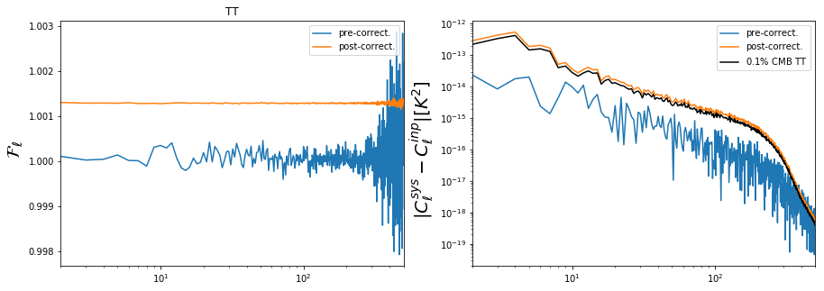

```python
fig=pl.figure(figsize=(15, 5))
ll=l*(l+1)/pl.pi/2.
pl.subplot(121)
pl.title('TT')

pl.ylabel(r'$\mathcal{F}_{\ell}$   ', fontsize=20)

pl.semilogx(l, abs  (cldrifts[0][2:]    /cl[0][2: ])  , label ='pre-correct.'  )
pl.semilogx(l, (cldriftcorr[0][2:] )   / cl[0][2: ]   , label='post-correct.' )
pl.legend(loc='upper right')
pl.xlim([2,500])

pl.subplot(122)
pl.ylabel(r'$ | C^{sys}_{\ell} - C^{inp}_{\ell} | [K^2] $   ', fontsize=20)

pl.loglog(l, abs  (cldrifts[0][2:]    -cl[0][2: ])  , label ='pre-correct.'  )
pl.loglog(l, abs(cldriftcorr[0][2:]    - cl[0][2: ] )   , label='post-correct.' )
pl.loglog(l, abs  ( cl[0][2: ])*1e-3 ,'k', label = r'$  0.1 \% $ CMB TT '  )

pl.legend(loc='upper right')
pl.xlim([2,lmax])
```

(left) The TT transfer function of pre and post correction spectra (respectively in blue and orange) presents very interesting features. By injecting the gain drifts the $\mathcal{F}_\ell$ looks as a sort of noise component fluctuating around $1$, being essentially noisier at higher multipoles. On the other hand, correcting the gain drifts reduces a lot the noise into the spectra but introducing an extra component whose spectrum is $0.1 \% C_\ell^{TT}$( solid black in right panel)

## EE

```
(2, 500)
```

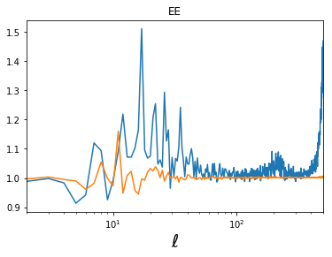

```python
pl.title('EE')
pl.semilogx(l,  (cldrifts[1][2:]  )/cl[1][2: ]  )
pl.semilogx(l, (cldriftcorr[1][2:]  )/cl[1][2: ]  )
pl.xlabel(r'$\ell $', fontsize=20 )
pl.xlim([2,500])
```

the EE transfer function post correction shows smaller fluctuations around $\ell \sim 10$ than the pre-correction case. The latter presenting also a bump at $\ell \sim 200 $ and an abroupt increase at higher multipoles.

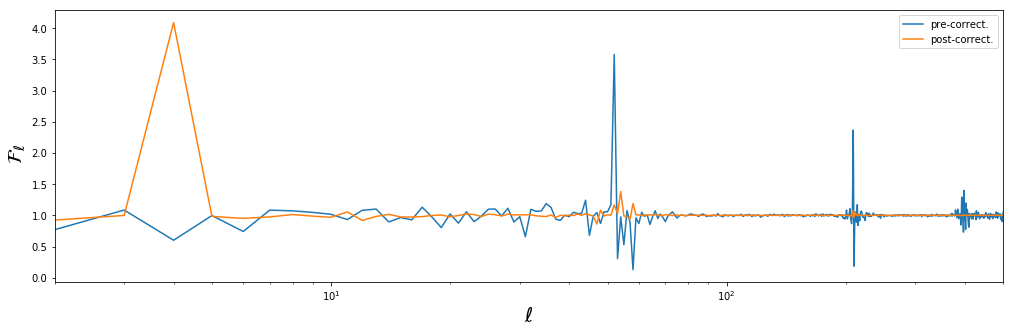

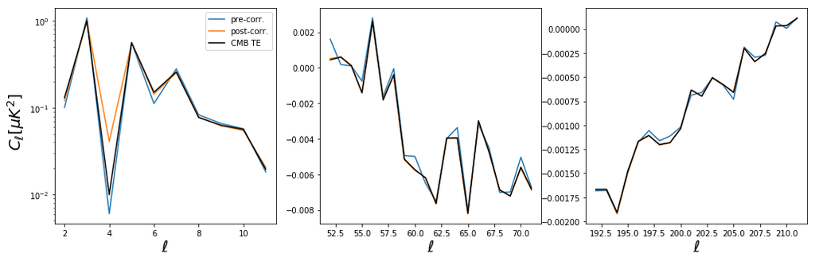

```python
fig=pl.figure(figsize=(17, 5))

pl.subplot(111)
pl.ylabel(r'$\mathcal{F}_{\ell}$   ', fontsize=20)

pl.semilogx(l, abs  (cldrifts[3][2:]    /cl[3][2: ])  , label ='pre-correct.'  )
pl.semilogx(l, (cldriftcorr[3][2:] )   / cl[3][2: ]   , label='post-correct.' )
pl.legend(loc='upper right')
pl.xlabel(r'$\ell $', fontsize=20 )

pl.xlim([2,500])
fig=pl.figure(figsize=(17, 5))

pl.subplot(131)
pl.ylabel(r'$C_{\ell}   [  \mu K^2] $   ', fontsize=20)
pl.xlabel(r'$\ell $', fontsize=20 )

pl.semilogy(l [:10], abs(cldrifts[3][2:12]*1e12   ) , label='pre-corr.'  )
pl.semilogy(l[:10] , abs(cldriftcorr[3][2:12]  )*1e12 , label='post-corr.'    )
pl.semilogy(l [:10], abs(cl [3][2:12]   ) *1e12, 'k'  , label='CMB TE ' )
pl.legend()

pl.subplot(132)

pl.xlabel(r'$\ell $', fontsize=20 )

pl.plot (l [50:70],  (cldrifts[3][52:72]*1e12   )   )
pl.plot(l[50:70 ] ,  (cldriftcorr[3][52:72]  )*1e12     )
pl.plot(l [50:70],  (cl [3][52:72]   ) *1e12, 'k'   )

pl.subplot(133)

pl.xlabel(r'$\ell $', fontsize=20 )

pl.plot (l [190:210], (cldrifts[3][192:212]*1e12   )   )
pl.plot(l[190:210 ] , (cldriftcorr[3][192:212]  )*1e12     )
pl.plot(l [190:210], (cl [3][192:212]   ) *1e12, 'k'   )
```

the TE transfer function presents similar features as in EE. The gain correction strongly leaves a factor of 4 bias at the $\ell =4 $ multipole. In the bottomo panels we show the TE power spectra without any systematic leakage (solid black) and pre and post- gain correction (resp. solid blue and orange ). We zoomed into the multipole regions where the transfer function fluctuates more, i.e. $\ell \sim 4, 60, 200 $.